# Aula 13

Mahayana Godoy

# Regressão logística

# Conteúdo do dia

Há outras maneiras de analisar dados em distribuição binominal além de um teste qui-quadrado.

Hoje aprenderemos como fazer isso. Discutiremos:

- o que são *logodds*
- o que é regressão logística
- como fazer uma regressão logística simples
- como analisar e escrever seus resultados

# Chances (odds) e probabilidades

# Chances (odds) e probabilidades

Vamos continuar jogando a nossa moeda imaginária. Coroa, eu ganho, cara, vocês ganham.

Jogamos as moedas 100 vezes. Eu tive 50 sucessos (coroa) e 50 fracassos (cara).

Qual ou quais das afirmações abaixo estão corretas?

1. A chance de sair coroa é de 1:1 (um para um)
2. A chance de sair coroa é de 50%
3. A probabilidade de sair coroa é de 0.5
- Resposta: todas!

# Chances (odds) e probabilidades

Vamos continuar jogando a nossa moeda imaginária. Coroa, eu ganho, cara, vocês ganham.

Jogamos a moeda algumas vezes. Eu tive 1 sucesso (coroa) e 10 fracassos (cara).

Qual ou quais das afirmações abaixo estão corretas?

1. a chance de sair coroa é de 1:10 (1 para 10).
2. a chance, em porcentagem, de sair coroa é de 10%.
3. a probabilidade de sair coroa é de 0.1.

# Chances (odds) e probabilidades

Vamos continuar jogando a nossa moeda imaginária. Coroa, eu ganho, cara, vocês ganham.

Jogamos a moeda algumas vezes. Eu tive 1 sucesso (coroa) e 10 fracassos (cara).

CORRIGINDO:

1. a chance de sair coroa é de 1:10 (1 para 10). **CORRETO**
2. a chance, em porcentagem, de sair coroa é de 10%. **CORREÇÃO: 9%**.
3. a probabilidade de sair coroa é de 0.1. **CORREÇÃO: 0.09 (ou 1/11)**.

# Chances (odds) e probabilidades

Vamos continuar jogando a nossa moeda imaginária. Coroa, eu ganho, cara, vocês ganham.

Jogamos as moedas 100 vezes. Eu tive 64 sucessos (coroa) e 36 fracassos (cara).

**Qual a chance (odds ratio) de sair coroa?**

- 64:36 ou 32:18 ou 16:9 (a cada 16 coroas, saem 9 caras) ou 1.77 (para cada cara, sai 1.77 coroas)

**Qual a probabilidade de sair coroa?**

- 0.64 (a cada 100 jogadas, saem 64 coroas (64/100))

# Chances (odds) e probabilidades

As chances de algo ocorrer é expressa numa razão da seguinte maneira:

**números de sucesso:numeros de fracasso**

| Porcentagem | Probabilidade | Chances (ou odds ratio) |
| --- | --- | --- |
| 50% | 0.5 | 1:1 ou 1 |
| 10% | 0.1 | 1:9 ou 0.11 |
| 90% | 0.9 | 9:1 ou 9 |
| 75% | 0.75 | 3:1 ou 3 |
| 80% | 0.8 | 8:2 ou 4:1 ou 4 |

Odds ratio (ou chances) é só uma outra maneira de expressar probabilidades. Você já deve ter ouvido isso na mídia, quando ouve algo como *“estudos indicam que quem fuma tem 10 vezes mais chances de desenvolver câncer”* (10:1).

# Chances (odds) e probabilidades

As chances de algo ocorrer é expressa numa razão da seguinte maneira:

**números de sucesso:numeros de fracasso**

| Porcentagem | Probabilidade | Chances (ou odds ratio) |
| --- | --- | --- |
| 50% | 0.5 | 1:1 ou 1 |
| 10% | 0.1 | 1:9 ou 0.11 |
| 90% | 0.9 | 9:1 ou 9 |
| 75% | 0.75 | 3:1 ou 3 |
| 80% | 0.8 | 8:2 ou 4:1 ou 4 |

Quando comparamos a chance de sucesso entre dois grupos, A e B, um teste estatístico vai tentar responder a seguinte pergunta: *A chance de sucesso no grupo A aumenta ou diminuiu em relação ao grupo B? Em quantas vezes? Essa mudança é significativamente diferente de 0?*

# Chances (odds) e probabilidades

As chances de algo ocorrer é expressa numa razão da seguinte maneira:

**números de sucesso:numeros de fracasso**

| Porcentagem | Probabilidade | Chances (ou odds ratio) |
| --- | --- | --- |
| 50% | 0.5 | 1:1 ou 1 |
| 10% | 0.1 | 1:9 ou 0.11 |
| 90% | 0.9 | 9:1 ou 9 |
| 75% | 0.75 | 3:1 ou 3 |
| 80% | 0.8 | 8:2 ou 4:1 ou 4 |

**Valores de probabilidade:** 0 a 1

**Valores de Odds Ratio:** 0 a infinito

# Regressão Logística

# O que é?

Vamos analisar novamente os dados de Labov por loja.

```r
tabela.lojas = table(labov$r, labov$store)
tabela.lojas
```

**Tabela de frequência absoluta**

|  | Klein | Macys | Saks |
| --- | --- | --- | --- |
| r0 | 195 | 211 | 93 |
| r1 | 21 | 125 | 85 |

**Tabela com odds ratio por loja**

| Lojas | Chances (ou odds ratio) |
| --- | --- |
| Klein | 21:195 ou 0.107 |
| Macys | 125:211 ou 0.592 |
| Sacks | 85:93 ou 0.913 |

# Regressão: ajuste

Vamos ajustar um modelo de regressão logística. A função que usamos é `glm()` - porque uma regressão logística é um modelo linear generalizado - e a sintaxe você já conhece de outros carnavais (lm, anova…). Os modelos lineares generalizados conseguem lidar com dados de inúmeras famílias de distribuição. No código abaixo, informamos que nossa VD é uma *binomial*.

```r
labov.loja = glm(r ~ store, labov, family = binomial)
```

Após ajustar o modelo, vemos o seu resultado com a função summary, assim como fizemos para os outros modelos lineares.

```r
summary(labov.loja)
```

# Resultado glm()

```
##
## Call:
## glm(formula = r ~ store, family = binomial, data = labov)
##
## Deviance Residuals:
##     Min       1Q   Median       3Q      Max
## -1.1395  -0.9646  -0.4523   1.2158   2.1591
##
## Coefficients:
##             Estimate Std. Error z value Pr(>|z|)
## (Intercept)  -2.2285     0.2296  -9.704  < 2e-16 ***
## storeMacys    1.7049     0.2559   6.663 2.68e-11 ***
## storeSaks     2.1385     0.2743   7.796 6.41e-15 ***
## ---
## Signif. codes:  0 '***' 0.001 '**' 0.01 '*' 0.05 '.' 0.1 ' ' 1
##
## (Dispersion parameter for binomial family taken to be 1)
##
##     Null deviance: 911.27  on 729  degrees of freedom
## Residual deviance: 827.72  on 727  degrees of freedom
## AIC: 833.72
##
## Number of Fisher Scoring iterations: 4
```

# Resultado glm()

Vamos começar tentando entender o que o valor dos coeficientes querem dizer.

|  | Estimate | Std. Error | z value | Pr(>\|z\|) |
| --- | --- | --- | --- | --- |
| (Intercept) | -2.228477 | 0.2296425 | -9.704114 | 0 |
| storeMacys | 1.704933 | 0.2558809 | 6.662994 | 0 |
| storeSaks | 2.138529 | 0.2743229 | 7.795662 | 0 |

O output é similar ao que vimos para modelos lineares. Aqui, entendemos que a loja *Klein* está no lugar de intercept. Isso significa que o modelo está comparando a distribuição do rótico da *Macys* com a *Klein* (segunda linha da tabela) e da *Saks* com a *Klein* (terceira linha da tabela).

Mas o que os valores de *Estimate* querem dizer? Vamos começar com o Estimate do intercept.

# Resultado glm()

Em primeiro lugar, é importante saber o que o teste reporta sobre o uso do rótico. A regressão compara a proporção de uso do nível de não-referência com o nível de referência. Parece confuso? Vamos dar uma olhada em quais são os níveis da nossa variável dependente.

```r
levels(labov$r)
```

```
## [1] "r0" "r1"
```

O comando `levels()` nos indica que o primeiro nível (o valor de referência) é r0 (porque o R segue ordem alfatbética e numéria, e r0 vem antes de r1). No intercept, a regressão está comparando, portanto, as taxas de r1 com as taxas do nível de referência, que é r0.

Vamos dar uma olhada nos valores do coeficiente mais uma vez.

# Resultado glm()

Veja que o valor de Estimate no intercept é negativo.

|  | Estimate | Std. Error | z value | Pr(>\|z\|) |
| --- | --- | --- | --- | --- |
| (Intercept) | -2.228477 | 0.2296425 | -9.704114 | 0 |
| storeMacys | 1.704933 | 0.2558809 | 6.662994 | 0 |
| storeSaks | 2.138529 | 0.2743229 | 7.795662 | 0 |

Isso significa que, no Intercept (que aqui é a loja *Klein*), há menos ocorrências de r1 do que r0 - o que já sabíamos. Mais que isso, vemos que a diferença entre as taxas é significativa (veja o p-valor).

Mas por que -2.228477? De onde veio esse valor?

# Resultado glm()

Em vez de reportar a *odds ratio* de r1 frente a r0 para Klein, que vimos que era de 21:195 ou 0.107, o output de um modelo linear usa o logaritmo desse valor. Vamos ver qual é o logaritmo de 21:195:

```r
log(21/195)
```

```
## [1] -2.228477
```

Ou seja, o output do seu modelo está informando que a taxa de r1 é de 0.107 para cada r0. A única diferença é que ele está fazendo isso de uma forma um pouco mais complicado. Mas por quê?

# Log Odds

O logaritmo da odds ratio, ou *log odds* tem a vantagem de ser um número que pode assumir valores negativos; dessa maneira, podemos saber o sentido da diferença.

**Tabela com odds ratio e log odds por loja**

| Lojas | Chances (ou odds ratio) | Log odds |
| --- | --- | --- |
| Klein | 21:195 ou 0.107 | -2.228477 |
| Macys | 125:211 ou 0.592 | -0.5235444 |
| Sacks | 85:93 ou 0.913 | -0.0899482 |
| Loja Imaginária | 85:85 ou 1 | 0 |
| Klein Upsideworld | 195:21 ou 9.285714 | 2.228477 |
| Macys Upsideworld | 211:125 ou 1.688 | 0.5235444 |
| Sacks Upsideworld | 93:85 ou 1.094118 | 0.0899482 |

# Resultado glm()

Voltemos aos nossos coeficientes.

|  | Estimate | Std. Error | z value | Pr(>\|z\|) |
| --- | --- | --- | --- | --- |
| (Intercept) | -2.228477 | 0.2296425 | -9.704114 | 0 |
| storeMacys | 1.704933 | 0.2558809 | 6.662994 | 0 |
| storeSaks | 2.138529 | 0.2743229 | 7.795662 | 0 |

Se eu tenho o valor de *log odds* do intercept, consigo calcular chegar ao odds ratio usando a função exponencial. Veja:

```r
exp(-2.228477)
```

```
## [1] 0.1076923
```

Temos aqui o valor da *odds ratio* para a loja *Klein*, que já havíamos visto que era de 0.107!

# Resultado glm()

Voltemos novamente aos coeficientes.

|  | Estimate | Std. Error | z value | Pr(>\|z\|) |
| --- | --- | --- | --- | --- |
| (Intercept) | -2.228477 | 0.2296425 | -9.704114 | 0 |
| storeMacys | 1.704933 | 0.2558809 | 6.662994 | 0 |
| storeSaks | 2.138529 | 0.2743229 | 7.795662 | 0 |

Os valores dados para *Macys* e *Saks* não são seus log odds. Eles nem tem o mesmo sinal!

| Lojas | Chances (ou odds ratio) | Log odds |
| --- | --- | --- |
| Klein | 21:195 ou 0.107 | -2.228477 |
| Macys | 125:211 ou 0.592 | -0.5235444 |
| Sacks | 85:93 ou 0.913 | -0.0899482 |

Porquê?

# Resultado glm()

Lembremos que, em um modelo linear, o output dá os valores em relação ao intercept. Abaixo, o modelo nos informa que, com relação à *Klein*, o *log odds* de r1 de Macys é 1.704933 **maior**.

|  | Estimate | Std. Error | z value | Pr(>\|z\|) |
| --- | --- | --- | --- | --- |
| (Intercept) | -2.228477 | 0.2296425 | -9.704114 | 0 |
| storeMacys | 1.704933 | 0.2558809 | 6.662994 | 0 |
| storeSaks | 2.138529 | 0.2743229 | 7.795662 | 0 |

Como fica a conversão de 1.704933 de *log odds* para *odds ratio*?

```r
exp(1.704933)
```

```
## [1] 5.501017
```

Ou seja, as vendedoras da Macys tinham uma chance 5.5 vezes maior de produzir um r1 que as vendedoras de Klein.

# Resultado glm()

Podemos fazer o mesmo para a Saks.

|  | Estimate | Std. Error | z value | Pr(>\|z\|) |
| --- | --- | --- | --- | --- |
| (Intercept) | -2.228477 | 0.2296425 | -9.704114 | 0 |
| storeMacys | 1.704933 | 0.2558809 | 6.662994 | 0 |
| storeSaks | 2.138529 | 0.2743229 | 7.795662 | 0 |

Como fica a conversão de 2.138529 de *logodds* para *odds ratio*?

```r
exp(2.1385293)
```

```
## [1] 8.486947
```

# Resumindo a situação até agora

O qui-quadrado é um teste simples que permite saber se a proporção muda em função das lojas.

A regressão logística permite comparar com mais facilidade a variabilidade entre as lojas, para inferir qual delas difere das outras (ou se todas diferem entre si)

Ambos os testes exigem que tenhamos medidas independentes para as amostras comparadas e oriundas de uma distribuição binomial. Aqui, temos medidas independentes, pois os vendedores de uma loja não eram os vendedores das outras.

# Múltiplas comparações

# Múltiplas comparações

Seria interessante comparar as lojas entre si. Será que há diferença em relação à realização do rótico entre Macys e Saks?

Para fazer isso, usamos um pacote chamando “emmeans”, que faz análises post-hoc a partir do modelo linear ajustado. Você pode instalar e carregar o pacote com os comandos abaixo.

```r
install.packages("emmeans")
library(emmeans)
```

Abaixo, criamos o objeto *glm.labov.loja*. Esse objeto contém as múltiplas comparações possíveis para a variável *store* no modelo *labov.loja*.

```r
glm.labov.loja = emmeans(labov.loja, ~ store)
```

# Comparando as lojas

O comando `pairs()` permite ver as comparações previstas em *glm.labov.loja*, com o p-valor apresentado sendo ajustado por Tukey.

```r
pairs(glm.labov.loja, adjust="tukey")
```

```
##  contrast      estimate    SE  df z.ratio p.value
##  Klein - Macys   -1.705 0.256 Inf -6.663  <.0001
##  Klein - Saks    -2.139 0.274 Inf -7.796  <.0001
##  Macys - Saks    -0.434 0.188 Inf -2.309  0.0545
##
## Results are given on the log odds ratio (not the response) scale.
## P value adjustment: tukey method for comparing a family of 3 estimates
```

Os resultados mostram os valores em *logodds* da primeira loja do par em relação à segunda.

É possível apresentar os resultados por meio dessa tabela, ou escrever os coeficientes no meio do texto, como vemos a seguir.

# Escrevendo os resultados

“Posso incluir nos resultados os valores de odds ratio, para dizer que vendedores de Loja y tinham x vezes mais chances de produzir o rótico que vendedores da Loja w?”. Claro! No entanto, geralmente as pessoas reportam os *logodds*; portanto, não deixe de reportá-los também.

# Momento de prática

# Agora é a sua vez

Godoy, Weissheimer & Mafra (2018) testaram se a representação de um evento de transferência de posse influenciava o modo como as pessoas interpretavam um pronome ambíguo.

Para isso, eles pediram para as pessoas completarem sentenças como as que você abaixo, que continham três tipos de verbos de transferência de posse:

$João_\text{fonte}$ entregou a maçã para $Mário_\text{alvo}$. Ele… (verbo de Classe 1)

$Pedro_\text{fonte}$ jogou a chave para $Roberto_\text{alvo}$. Ele… (verbo de Classe 2)

$Sulei_\text{fonte}$ transferiu dinheiro para $Maria_\text{alvo}$. Ela… (verbo de Classe 3)

As respostas foram analisadas para ver se os participantes interpretaram o pronome como co-referente à fonte ou ao alvo do evento.

# Agora é a sua vez

**Variável preditora**

Os verbos de Classe 1, 2 e 3 tinham as seguintes características:

**Verbos de classe 1:** participantes necessariamente na mesma cena do evento; garantia de transferência

**Verbos de classe 2:** participantes necessariamente na mesma cena do evento; sem garantia de transferência

**Verbos de classe 3:** participantes não estão necessariamente na mesma cena do evento; sem garantia de transferência

# Agora é a sua vez

**Hipóteses**

Os autores imaginavam que pronomes em contextos de verbo do Tipo 3 teriam menor preferência por serem interpretados como co-referentes ao referente ocupando papel temático de alvo, pois ele estaria em menor evidência em comparação aos tipos 1 e 2, visto que não há necessidade de ele estar na cena do evento descrito pelo verbo.

Em contexto de verbos do tipo 1, haveria maior preferência por interpretar o pronome como co-referente ao alvo, pois a transferência é bem sucedida.

# Agora é a sua vez

**Tarefa**

- Filtre os dados da tabela “godoy_et_al.xlsx” para considerar apenas os dados com “source” (fonte) ou “goal” (alvo); não nos interessam os dados em que a interpretação foi ambígua.
- Faça um gráfico para averiguar a distribuição de fonte/alvo por tipo de verbo.
- Faça um qui-quadrado para ver se houve efeito de tipo de verbo.
- Faça uma regressão logística para ver se houve efeito do tipo de verbo e como foi esse efeito.
- Tente entender o que os valores dos coeficientes querem dizer.

# Agora é sua vez

# Agora é sua vez

Vamos dar uma olhada no conjunto de dados.

```
## 'data.frame':    864 obs. of  14 variables:
##  $ LISTA         : num  1.1 1.1 1.1 1.1 1.1 1.1 1.1 1.1 1.1 1.1 ...
##  $ participant   : Factor w/ 48 levels "ACBO","B A S",..: 33 19 4 40 30 31 45 12 33 19 ...
##  $ idade         : int  22 21 29 28 22 22 20 19 22 21 ...
##  $ cidade        : Factor w/ 21 levels "Amparo","An\x87polis - GO",..: 3 3 20 19 17 18 15 3 3 3 ...
##  $ genero        : Factor w/ 3 levels "Feminino","Masculino",..: 1 1 2 1 2 2 1 2 1 1 ...
##  $ escolaridade  : Factor w/ 1 level "Ensino Superior completo ou cursando": 1 1 1 1 1 1 1 1 1 1 ...
##  $ falantenativo : Factor w/ 1 level "Sim": 1 1 1 1 1 1 1 1 1 1 ...
##  $ item          : Factor w/ 18 levels "a","b","c","d",..: 14 14 14 14 14 14 14 14 8 8 ...
##  $ frase         : Factor w/ 37 levels "Ana estava jogando o travesseiro para Fl\x87via. Ela...",..: 24 24 24 24 24 24 24 24 16 16 ...
##  $ resposta      : Factor w/ 830 levels ", distra\x92da, o deixou cair na piscina.",..: 293 478 782 774 123 212 649 162 352 503 ...
##  $ pro_gender    : Factor w/ 2 levels "f","m": 1 1 1 1 1 1 1 1 2 2 ...
##  $ verbtype      : Factor w/ 3 levels "C1","C2","C3": 3 3 3 3 3 3 3 3 3 3 ...
##  $ verbaspect    : Factor w/ 2 levels "imperfective",..: 1 1 1 1 1 1 1 1 1 1 ...
##  $ interpretation: Factor w/ 5 levels "ambiguo","disagreement",..: 1 5 5 5 5 5 5 5 5 3 ...
```

# Agora é sua vez

Primeiro vamos filtrar o conjunto de dados com o dplyr. Abaixo, foi criado o conjunto “data” a partir da filtragem do conjunto “data.pre”. O comando `droplevels()` é importante para o conjunto de dados “esquecer” os outros níveis que haviam na variável “interpretation”

```r
data = data.pre%>%
  filter(interpretation=="source"|interpretation=="goal")%>%
  droplevels()
```

Agora fazemos o gráfico informando que o eixo x trará os tipos de verbos usados.

# Agora é sua vez

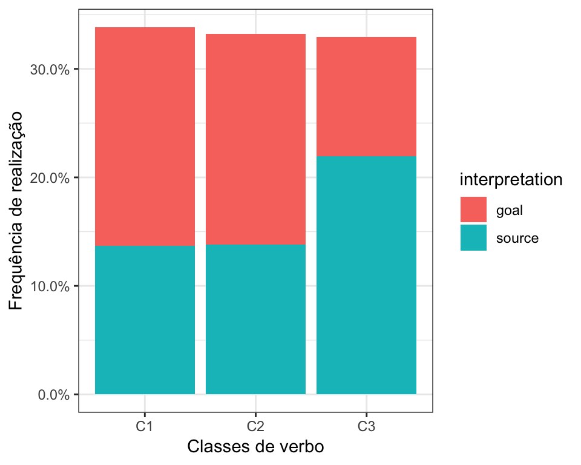

```r
ggplot(data, aes(x = verbtype, fill = interpretation)) +
  geom_bar(aes( y = (..count..)/sum(..count..))) +
  scale_y_continuous(labels=scales::percent)+
  labs(x = "Classes de verbo", y = "Frequência de realização")+
  theme_bw()
```

# Agora é sua vez

Vamos criar a tabela de observações para ver quanto de cada tipo de interpretação do pronome (source ou goal) há para cada tipo de verbo. Podemos também ver as proporções.

```r
tabela.pro = table(data$interpretation, data$verbtype)
tabela.pro
```

|  | C1 | C2 | C3 |
| --- | --- | --- | --- |
| goal | 159 | 153 | 87 |
| source | 108 | 109 | 173 |

```r
prop.table(tabela.pro, 2)
```

|  | C1 | C2 | C3 |
| --- | --- | --- | --- |
| goal | 0.5955056 | 0.5839695 | 0.3346154 |
| source | 0.4044944 | 0.4160305 | 0.6653846 |

# Agora é sua vez

Como nossa variável dependente tem uma distribuição binomial e nossa variável independente é categórica, podemos fazer um qui-quadrado para ver se há efeito de tipo de verbo na distribuição.

```r
chisq.test(tabela.pro)
```

```
##
##  Pearson's Chi-squared test
##
## data:  tabela.pro
## X-squared = 45.48, df = 2, p-value = 1.331e-10
```

# Agora é sua vez

O qui-quadrado nos diz que há um efeito de tipo de verbo na interpretação do pronome, mas não sabemos nada além disso. O ideal seria fazer uma regressão logística para ter mais informações. Vamos ver os níveis da variável dependente e ajustar o modelo.

```r
levels(data$interpretation)
```

```
## [1] "goal"   "source"
```

```r
model.pro = glm(interpretation ~ verbtype, data, family = binomial)
```

```r
summary(model.pro)
```

# Agora é sua vez

```
##
## Call:
## glm(formula = interpretation ~ verbtype, family = binomial, data = data)
##
## Deviance Residuals:
##    Min      1Q  Median      3Q     Max
## -1.480  -1.037  -1.018   1.324   1.345
##
## Coefficients:
##             Estimate Std. Error z value Pr(>|z|)
## (Intercept) -0.38677    0.12469  -3.102  0.00192 **
## verbtypeC2   0.04768    0.17680   0.270  0.78739
## verbtypeC3   1.07416    0.18117   5.929 3.05e-09 ***
## ---
## Signif. codes:  0 '***' 0.001 '**' 0.01 '*' 0.05 '.' 0.1 ' ' 1
##
## (Dispersion parameter for binomial family taken to be 1)
##
##     Null deviance: 1093.7  on 788  degrees of freedom
## Residual deviance: 1047.6  on 786  degrees of freedom
## AIC: 1053.6
##
## Number of Fisher Scoring iterations: 4
```

# Agora é sua vez

O intercept nos diz apenas que o *logodds* de source para verbos do tipo 1 é menor que 0. Isso indica que a taxa de interpretação como fonte é significativamente menor que 50% nesse caso, mas isso não nos interessa muito.

O resultado indica que não há diferença nas taxas de interpretação de fonte para verbos do tipo 1 e 2, mas há entre verbos do tipo 1 e 3. Será que há entre verbos do tipo 2 e 3? Para testar isso, temos que fazer múltiplas comparações. Abaixo, criamos o objeto *model.glm* com as análises *post-hoc* por tipo de verbo.

```r
model.glm = emmeans(model.pro, ~ verbtype)
```

# Agora é sua vez

Por fim, o comando `pairs()` permite ver as comparações do objeto model.glm com os valores de p ajustados (aqui, escolhemos ajuste pelo método de Tukey).

```r
pairs(model.glm, adjust="tukey")
```

```
##  contrast estimate    SE  df z.ratio p.value
##  C1 - C2   -0.0477 0.177 Inf -0.270  0.9607
##  C1 - C3   -1.0742 0.181 Inf -5.929  <.0001
##  C2 - C3   -1.0265 0.182 Inf -5.652  <.0001
##
## Results are given on the log odds ratio (not the response) scale.
## P value adjustment: tukey method for comparing a family of 3 estimates
```

# Agora é sua vez

**Resposta** *Ajustamos um modelo de regressão logística com a interpretação do pronome ambíguo como variável resposta e o tipo de verbo como variável preditora. Para fazer as múltiplas comparações dos três níveis da variável preditora, realizamos um teste post-hoc (p-valor ajustado pelo método de Tukey). Os resultados mostraram que os pronomes ambíguos tiveram menos interpretações de fonte quando seguiam verbos do tipo 1 e 2 do que quando seguiam verbos do tipo 3 (Tipo 1 vs Tipo 3: $\beta$ = -1.07415645, z = -5.929, p < 0.0001; Tipo 2 vs Tipo 3: $\beta$ = -1.02647352, z = -5.652, p < 0.0001). Não houve diferenças quanto à interpretação do pronome após sentenças com verbos do Tipo 1 ou verbos do Tipo 2 ($\beta$ = -0.04768294, z = -0.270, p < 0.9607)*

# Outra vantagem do modelo linear generalizado

# Outra vantagem do modelo linear generalizado

Ao contrário do qui-quadrado, ajustar um modelo linear generalizado para dados em distribuição binomial (que é o que chamamos de “regressão logística”) permite que sua variável independente seja quantitativa.

Lembra do experimento sobre Laurel e Yanny (HW11)? Vamos ajustar um modelo para ver se a escolha por Laurel ou Yanny muda em função da idade.

```r
levels(data$decision)
```

```
## [1] "Laurel" "Yanni"
```

```r
model.yl = glm(decision ~ age, data, family = binomial)
```

# Outra vantagem do MLG

```r
summary(model.yl)
```

```
##
## Call:
## glm(formula = decision ~ age, family = binomial, data = data)
##
## Deviance Residuals:
##    Min      1Q  Median      3Q     Max
## -1.303  -1.286   1.062   1.072   1.104
##
## Coefficients:
##              Estimate Std. Error z value Pr(>|z|)
## (Intercept)  0.320080   0.327697   0.977    0.329
## age         -0.002254   0.011003  -0.205    0.838
##
## (Dispersion parameter for binomial family taken to be 1)
##
##     Null deviance: 602.82  on 439  degrees of freedom
## Residual deviance: 602.78  on 438  degrees of freedom
## AIC: 606.78
##
## Number of Fisher Scoring iterations: 3
```

# Outra vantagem do MLG

O valor do coeficiente (-0.002254) indica o quanto muda a escolha de yanny em relação a laurel com a idade. Como o valor é negativo, entendemos que a proporção de pessoas que escolhe yanny diminui.

No entanto, o output indica que a decisão por yanny ou laurel não muda de forma significativa em função da idade (veja o p-valor e o tamanho do coeficiente, que é bem próximo de 0).

A interpretação do coeficiente para um regressão logística com variável independente quantitativa é um pouco complicada.

Sabemos que é possível transformar logodds (a unidade dos coeficientes) em *odds ratio*, mas como essa transformação não é linear, não é tão simples expressar a mudança dada pelo coeficiente em forma de odds ratio nesse contexto.

Se quiser saber mais, [**esse texto**](http://www.mypolyuweb.hk/~sjpolit//logisticregression.html) trata do assunto.

# Revisão

# Ajuste de modelo

O ajuste de um modelo para regressão logística prevê o uso da função `glm()`. As comparações post-hoc podem ser feitas com `emmeans()`

```r
modelo = glm(var_dependente ~ var_independente, dados, family = binomial)

glm.model = emmeans(modelo, ~ var_independente)
pairs(glm.model, adjust="tukey")
```